# ML_Project_Overview_Demo

## ML Project Workflow - Preprocessing Demonstration

1. A Quick Look at the Data Structure.
2. Exploring Data Analysis
3. Feature Engineering
4. Data Split

```python
import pandas as pd
```

```python
DF = pd.read_csv('Housing.csv')
```

### 1. A Quick Look at the Data Structure.

```python
DF.shape
```

```
(20640, 10)
```

```python
print(list(DF.columns))
```

```
['longitude', 'latitude', 'housing_median_age', 'total_rooms', 'total_bedrooms', 'population', 'households', 'median_income', 'median_house_value', 'ocean_proximity']
```

```python
DF.head(5)
```

|  | longitude | latitude | housing_median_age | total_rooms | total_bedrooms | population | households | median_income | median_house_value | ocean_proximity |
| --- | --- | --- | --- | --- | --- | --- | --- | --- | --- | --- |
| 0 | -122.23 | 37.88 | 41 | 880 | 129.0 | 322 | 126 | 8.3252 | 452600 | NEAR BAY |
| 1 | -122.22 | 37.86 | 21 | 7099 | 1106.0 | 2401 | 1138 | 8.3014 | 358500 | NEAR BAY |
| 2 | -122.24 | 37.85 | 52 | 1467 | 190.0 | 496 | 177 | 7.2574 | 352100 | NEAR BAY |
| 3 | -122.25 | 37.85 | 52 | 1274 | 235.0 | 558 | 219 | 5.6431 | 341300 | NEAR BAY |
| 4 | -122.25 | 37.85 | 52 | 1627 | 280.0 | 565 | 259 | 3.8462 | 342200 | NEAR BAY |

- There are 10 columns - `longitude`, `latitude`, `housing_median_age`, `total_rooms`, `total_bedrooms`, `population`, `households`, `median_income`, `median_house_value`, `ocean_proximity`.
- use `shape` to find the size of data - 20640 rows and 10 columns. We are going to treat the problem as a supervised learning problem to predict `meadian_house_value` which we will call it a **target** and the rest **features**, **predictors**, or **attributes**. We call the rows **examples** or **observations**
- use `head` to observe how data looks is structured. However, it does not give descriptions of data.

```python
DF.info()
```

```
<class 'pandas.core.frame.DataFrame'>
RangeIndex: 20640 entries, 0 to 20639
Data columns (total 10 columns):
 #   Column              Non-Null Count  Dtype
---  ------              --------------  -----
 0   longitude           20640 non-null  float64
 1   latitude            20640 non-null  float64
 2   housing_median_age  20640 non-null  int64
 3   total_rooms         20640 non-null  int64
 4   total_bedrooms      20433 non-null  float64
 5   population          20640 non-null  int64
 6   households          20640 non-null  int64
 7   median_income       20640 non-null  float64
 8   median_house_value  20640 non-null  int64
 9   ocean_proximity     20640 non-null  object
dtypes: float64(4), int64(5), object(1)
memory usage: 1.6+ MB
```

- use `info` to look for number of rows, and each attribute's type and number of non-null values.
- notice `total_bedrooms` has only 20,433 non-null values while other attributes have 20,640 non-null values. This means that `total_bedrooms` have 207 missing values or *no observations*.
- all attributes are numerical except the `ocean_proximity`. We see that this is a text data.

```python
DF["ocean_proximity"].value_counts()
```

```
<1H OCEAN     9136
INLAND        6551
NEAR OCEAN    2658
NEAR BAY      2290
ISLAND           5
Name: ocean_proximity, dtype: int64
```

```python
DF.describe()
```

|  | longitude | latitude | housing_median_age | total_rooms | total_bedrooms | population | households | median_income | median_house_value |
| --- | --- | --- | --- | --- | --- | --- | --- | --- | --- |
| count | 20640.000000 | 20640.000000 | 20640.000000 | 20640.000000 | 20433.000000 | 20640.000000 | 20640.000000 | 20640.000000 | 20640.000000 |
| mean | -119.569704 | 35.631861 | 28.639486 | 2635.763081 | 537.870553 | 1425.476744 | 499.539680 | 3.870671 | 206855.816909 |
| std | 2.003532 | 2.135952 | 12.585558 | 2181.615252 | 421.385070 | 1132.462122 | 382.329753 | 1.899822 | 115395.615874 |
| min | -124.350000 | 32.540000 | 1.000000 | 2.000000 | 1.000000 | 3.000000 | 1.000000 | 0.499900 | 14999.000000 |
| 25% | -121.800000 | 33.930000 | 18.000000 | 1447.750000 | 296.000000 | 787.000000 | 280.000000 | 2.563400 | 119600.000000 |
| 50% | -118.490000 | 34.260000 | 29.000000 | 2127.000000 | 435.000000 | 1166.000000 | 409.000000 | 3.534800 | 179700.000000 |
| 75% | -118.010000 | 37.710000 | 37.000000 | 3148.000000 | 647.000000 | 1725.000000 | 605.000000 | 4.743250 | 264725.000000 |
| max | -114.310000 | 41.950000 | 52.000000 | 39320.000000 | 6445.000000 | 35682.000000 | 6082.000000 | 15.000100 | 500001.000000 |

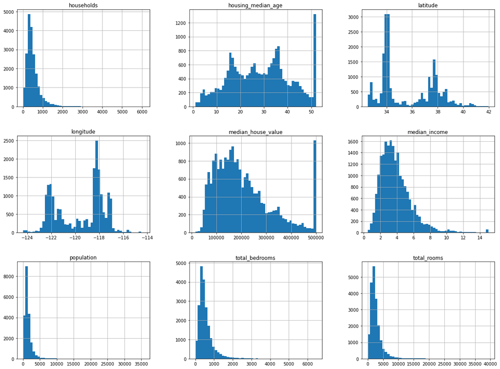

```python
import matplotlib.pyplot as plt
DF.hist(bins=50, figsize=(20,15))
plt.show()
```

### 2. Exploring Data Analysis

2-1. Visualization

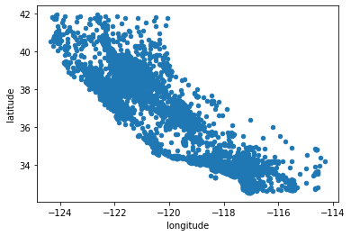

```python
DF.plot(kind="scatter",x="longitude",y="latitude")
```

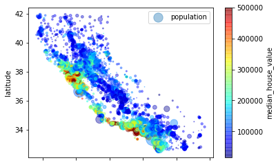

```python
DF.plot(kind="scatter",x="longitude",y="latitude", alpha=0.4, s=DF["population"]/100,
       label="population",c="median_house_value", cmap=plt.get_cmap("jet"),colorbar=True)
plt.legend()
```

3-2. Correlations

We can use `corr()` to compute the *standard correlation coeficient* also known as (*Pearson's r*) between every pair of features.

- The coefficent ranges from -1 to 1. Closer to 1 means that there is a strong positievv correlation and being closer to 0 means that there is no correlation.

```python
corr_matrix = DF.corr()
```

```python
corr_matrix["median_house_value"].sort_values(ascending=False)
```

```
median_house_value    1.000000
median_income         0.688075
total_rooms           0.134153
housing_median_age    0.105623
households            0.065843
total_bedrooms        0.049686
population           -0.024650
longitude            -0.045967
latitude             -0.144160
Name: median_house_value, dtype: float64
```

- the `median_house_value` tends to go up when the `median_income` goes up.
- the `median_house_value` tends to go down as `latitude` and `longitude` goes up.
- the `median_income` has the strongest correlation.

```python
from pandas.plotting import scatter_matrix
```

[output not shown]

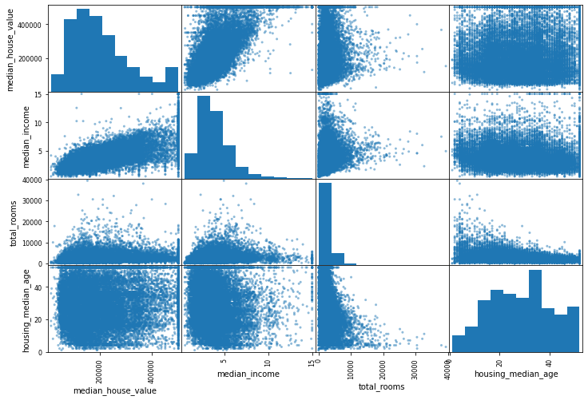

```python
features = ["median_house_value", "median_income", "total_rooms", "housing_median_age"]
scatter_matrix(DF[features], figsize=(12,8))
```

- For details, read the link: https://pandas.pydata.org/docs/reference/api/pandas.plotting.scatter_matrix.html
- the most promising feature to predict the `median_house_income` is the `median_income`.

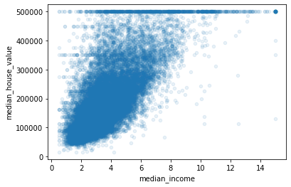

```python
DF.plot(kind="scatter", x="median_income",y="median_house_value", alpha=0.1)
```

- the correlation is strong.
- there is a price cap having a horizontal line at $500,000.

### 3. Feature Engineering

3-1. New Combinded Features

Consider the following arguement:

1. the `total_rooms` is not useful if the `household` is not known.
2. the `total_bedrooms` itself is not useful if the `total_rooms` is not known.
3. the arguments above does not come from ML experience, but more from how well deeply we about the data and the case.

```python
DF["rooms_per_household"]=DF["total_rooms"]/DF["households"]
DF["bedrooms_per_room"]=DF["total_bedrooms"]/DF["total_rooms"]
DF["population_per_household"]=DF["population"]/DF["households"]
```

```python
corr_matrix=DF.corr()
corr_matrix["median_house_value"].sort_values(ascending=False)
```

```
median_house_value          1.000000
median_income               0.688075
rooms_per_household         0.151948
total_rooms                 0.134153
housing_median_age          0.105623
households                  0.065843
total_bedrooms              0.049686
population_per_household   -0.023737
population                 -0.024650
longitude                  -0.045967
latitude                   -0.144160
bedrooms_per_room          -0.255880
Name: median_house_value, dtype: float64
```

3-2. Data Cleaning

```python
DF.info()
```

```
<class 'pandas.core.frame.DataFrame'>
RangeIndex: 20640 entries, 0 to 20639
Data columns (total 13 columns):
 #   Column                    Non-Null Count  Dtype
---  ------                    --------------  -----
 0   longitude                 20640 non-null  float64
 1   latitude                  20640 non-null  float64
 2   housing_median_age        20640 non-null  int64
 3   total_rooms               20640 non-null  int64
 4   total_bedrooms            20433 non-null  float64
 5   population                20640 non-null  int64
 6   households                20640 non-null  int64
 7   median_income             20640 non-null  float64
 8   median_house_value        20640 non-null  int64
 9   ocean_proximity           20640 non-null  object
 10  rooms_per_household       20640 non-null  float64
 11  bedrooms_per_room         20433 non-null  float64
 12  population_per_household  20640 non-null  float64
dtypes: float64(7), int64(5), object(1)
memory usage: 2.0+ MB
```

Missing Value Handling:

- Impute with averge, median, any specific number (.e.g, 0), or drop
- Use `fillna()` to fill in missing values
- If we decided to drop, we must consider dropping the column or the rows.
  - use `dropna()` to delete all rows for having a column with missing values.
  - use `drop()` to delete the column.

```python
DF.dropna(subset=['total_bedrooms']).shape
```

```
(20433, 13)
```

```python
DF.drop("total_bedrooms",axis=1).shape
```

```
(20640, 12)
```

```python
median=DF["total_bedrooms"].median()
average=DF["total_bedrooms"].mean()
print("median is",median)
print("average is", average)
```

```
median is 435.0
average is 537.8705525375618
```

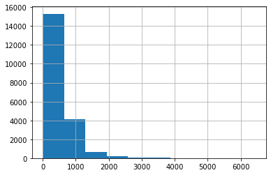

```python
DF["total_bedrooms"].hist()
```

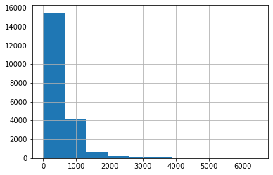

```python
DF["total_bedrooms"].fillna(median).hist()
```

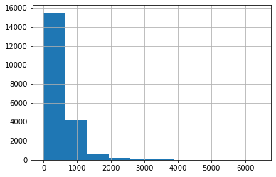

```python
DF["total_bedrooms"].fillna(average).hist()
```

3-3 Handling Categorical and Text Data:

- Most ML algorithms prefer to work with numbers. Therefore, converting text labels to numbers may bring meaningful information about data than just dropping.
- The `ocean_proximity` is in text and we cau use `LabelEncoder()` to convert the text to numbers.

```python
from sklearn.preprocessing import LabelEncoder
encoder = LabelEncoder()
DF_cat = DF["ocean_proximity"]
DF_cat_encoded = encoder.fit_transform(DF_cat)
DF_cat_encoded
```

```
array([3, 3, 3, ..., 1, 1, 1])
```

```python
print(encoder.classes_)
```

```
['<1H OCEAN' 'INLAND' 'ISLAND' 'NEAR BAY' 'NEAR OCEAN']
```

- `OneHotEncoder()` encorder converts inteter categorical values into one-hot vectors.
- Note that `fit_transform()` expects 2-D array and we need to reshape `DF_cat_encoded` because it is in 1-D array.

```python
from sklearn.preprocessing import OneHotEncoder
```

```python
encoder=OneHotEncoder()
DF_cat_encoded_1hot=encoder.fit_transform(DF_cat_encoded.reshape(-1,1))
DF_cat_encoded_1hot
```

```
<20640x5 sparse matrix of type '<class 'numpy.float64'>'
	with 20640 stored elements in Compressed Sparse Row format>
```

```python
DF_cat_encoded_1hot.toarray()
```

```
array([[0., 0., 0., 1., 0.],
       [0., 0., 0., 1., 0.],
       [0., 0., 0., 1., 0.],
       ...,
       [0., 1., 0., 0., 0.],
       [0., 1., 0., 0., 0.],
       [0., 1., 0., 0., 0.]])
```

- We get a matrix with 5 columns with 0 and 1 per row.
- We can use `LabelBinarizer()` to do the same work in one shot.

```python
from sklearn.preprocessing import LabelBinarizer
encoder=LabelBinarizer()
DF_cat_encoded_1hot=encoder.fit_transform(DF_cat_encoded)
DF_cat_encoded_1hot
```

```
array([[0, 0, 0, 1, 0],
       [0, 0, 0, 1, 0],
       [0, 0, 0, 1, 0],
       ...,
       [0, 1, 0, 0, 0],
       [0, 1, 0, 0, 0],
       [0, 1, 0, 0, 0]])
```

```python
DF_Encoded=pd.DataFrame(DF_cat_encoded_1hot)
```

```python
DF_Encoded.head(5)
```

|  | 0 | 1 | 2 | 3 | 4 |
| --- | --- | --- | --- | --- | --- |
| 0 | 0 | 0 | 0 | 1 | 0 |
| 1 | 0 | 0 | 0 | 1 | 0 |
| 2 | 0 | 0 | 0 | 1 | 0 |
| 3 | 0 | 0 | 0 | 1 | 0 |
| 4 | 0 | 0 | 0 | 1 | 0 |

```python
DF_Encoded.columns=['<1H OCEAN','INLAND','ISLAND','NEAR BAY','NEAR OCEAN']
```

```python
DF_Encoded.head(5)
```

|  | <1H OCEAN | INLAND | ISLAND | NEAR BAY | NEAR OCEAN |
| --- | --- | --- | --- | --- | --- |
| 0 | 0 | 0 | 0 | 1 | 0 |
| 1 | 0 | 0 | 0 | 1 | 0 |
| 2 | 0 | 0 | 0 | 1 | 0 |
| 3 | 0 | 0 | 0 | 1 | 0 |
| 4 | 0 | 0 | 0 | 1 | 0 |

```python
DF_final = pd.concat([DF, DF_Encoded], axis=1)
DF_final1=DF_final.drop('ocean_proximity',axis=1)
```

```python
DF_final1.info()
```

```
<class 'pandas.core.frame.DataFrame'>
RangeIndex: 20640 entries, 0 to 20639
Data columns (total 17 columns):
 #   Column                    Non-Null Count  Dtype
---  ------                    --------------  -----
 0   longitude                 20640 non-null  float64
 1   latitude                  20640 non-null  float64
 2   housing_median_age        20640 non-null  int64
 3   total_rooms               20640 non-null  int64
 4   total_bedrooms            20433 non-null  float64
 5   population                20640 non-null  int64
 6   households                20640 non-null  int64
 7   median_income             20640 non-null  float64
 8   median_house_value        20640 non-null  int64
 9   rooms_per_household       20640 non-null  float64
 10  bedrooms_per_room         20433 non-null  float64
 11  population_per_household  20640 non-null  float64
 12  <1H OCEAN                 20640 non-null  int64
 13  INLAND                    20640 non-null  int64
 14  ISLAND                    20640 non-null  int64
 15  NEAR BAY                  20640 non-null  int64
 16  NEAR OCEAN                20640 non-null  int64
dtypes: float64(7), int64(10)
memory usage: 2.7 MB
```

### 4. Data Split

```python
import numpy as np
from sklearn.model_selection import train_test_split
train_set, test_set = train_test_split(DF, test_size=0.2, random_state=42)
```

```python
print(len(train_set),"train +", len(test_set),"test")
```

```
16512 train + 4128 test
```

- `train_test_split` is the simplest function to split data.
- `random_state`: allows to set the random generator seed, pass it multiple datasets with an identical number of rows, and split them on the same indices.